# Remote_Work_Impact

#### Recommendations To Mange Stress Of Remote Work Location :

1. **Conduct an Employee Stress and Work Preference Survey**
   - Identify stress causes among remote employees (e.g., workload, communication challenges).
   - Collect preferences for work setups (remote, on-site, hybrid) and reasons for choices.
   - Gather suggestions on resources or support to enhance their work experience.
2. **Offer Remote Work Training Programs**
   - Train employees on work-life balance, stress management, and effective collaboration.
   - Include modules on mental health awareness and maintaining productivity.
3. **Implement Regular Check-Ins and Feedback Mechanisms**
   - Schedule consistent check-ins to monitor stress levels and provide support.
   - Establish anonymous feedback channels for employee concerns and suggestions.
   - Use feedback to identify and address recurring stressors.

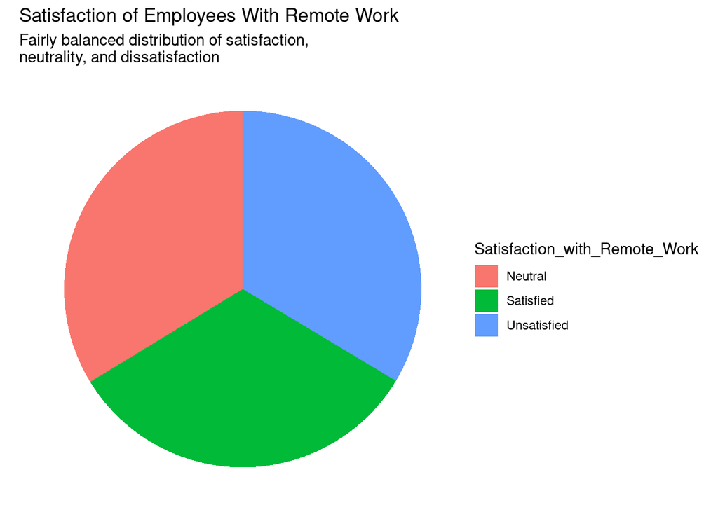

```r
remote_work %>%
  filter(Work_Location == "Remote") %>%
  count(Satisfaction_with_Remote_Work) %>%
  ggplot(aes(x = "", y = n, fill = Satisfaction_with_Remote_Work)) +
  geom_bar(stat = "identity", width = 1) +
  coord_polar(theta = "y") +
  labs(title = "Satisfaction of Employees With Remote Work ", subtitle = "Fairly balanced distribution of satisfaction,
neutrality, and dissatisfaction ") +
  theme_void()
```